# Joint modifiers and extreme bleaching mortality

Coherent Acropora terms, a severe-tail learner, and INLA/BRT blending.

## Decision

- Keep all zeros in the Bernoulli occurrence component.
- Use Acropora proportion, total pre-event cover and their DHW interaction.
- Retain the bounded-response INLA/BRMS model and nonlinear BRT as generalists. Add the tail BRT as an event-risk expert, not a universal replacement.
- Use conservative or nested-CV ensemble weights for routine maps and show the soft gate separately as a high-risk estimate.

Across 537 reef-blocked predictions, the standard BRT predicts 28.1% for cases that exceed 50%. Conservative and soft tail learners raise this to 32.5% and 36.9%; pooled RMSE changes from 15.7% to 15.3% and 15.4%. False extremes among observations below 30% rise from 4.1% to 5.9% and 8.3%.

## Acropora parameterisation

All alternatives include total pre-event cover and use identical reef-blocked folds. Absolute Acropora cover is a useful sensitivity, but including it with proportion is not consistently better and recreates correlated terms.

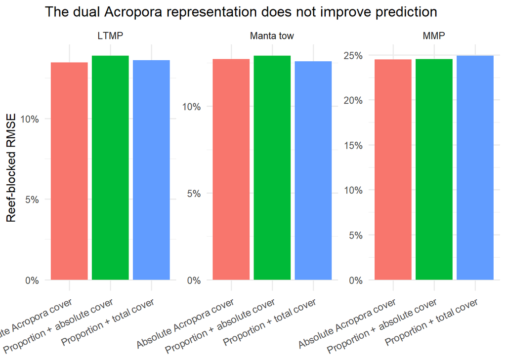

Proportion plus total cover is the clearest common basis: proportion describes susceptibility and total cover describes how much coral was available to lose. Absolute cover is slightly better for LTMP and MMP but worse for Manta, so it remains a sensitivity rather than an additional default term.

## Tail learner trade-off

The standard model predicts $E(M)=P(M>0)E(M\mid M>0)$. The specialist also estimates the probability and magnitude of mortality at or above 30%. This threshold is a modelling device, not an ecological discontinuity.

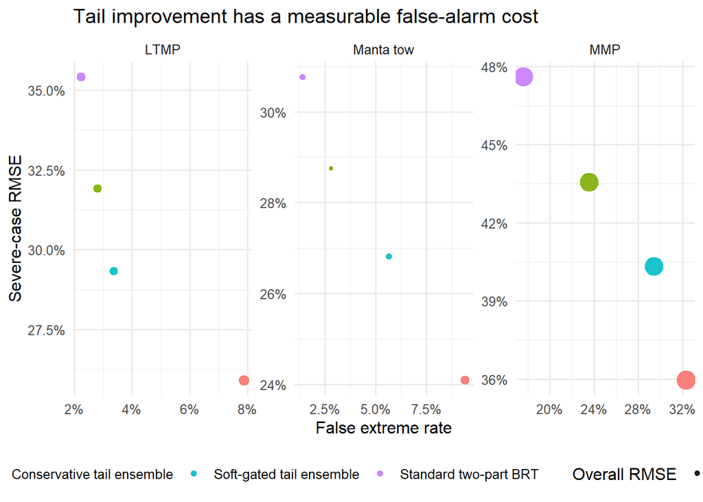

Reef-blocked performance for the 2024 event

| Programme | Model | N | Severe N | RMSE | Bias | Severe observed | Severe predicted | False extreme |
| --- | --- | --- | --- | --- | --- | --- | --- | --- |
| LTMP | Conservative tail ensemble | 75 | 4 | 13.4% | 1.5% | 62.0% | 46.4% | 7.4% |
| LTMP | Soft-gated tail ensemble | 75 | 4 | 13.7% | 2.9% | 62.0% | 52.9% | 8.8% |
| LTMP | Standard two-part BRT | 75 | 4 | 13.6% | 0.1% | 62.0% | 39.8% | 5.9% |
| Manta tow | Conservative tail ensemble | 89 | 6 | 16.9% | -2.6% | 58.0% | 33.3% | 6.2% |
| Manta tow | Soft-gated tail ensemble | 89 | 6 | 16.9% | -1.1% | 58.0% | 35.2% | 10.9% |
| Manta tow | Standard two-part BRT | 89 | 6 | 17.2% | -4.1% | 58.0% | 31.4% | 4.7% |
| MMP | Conservative tail ensemble | 54 | 13 | 28.3% | -1.9% | 64.4% | 29.5% | 25.0% |
| MMP | Soft-gated tail ensemble | 54 | 13 | 27.8% | 0.8% | 64.4% | 35.0% | 36.1% |
| MMP | Standard two-part BRT | 54 | 13 | 29.5% | -4.6% | 64.4% | 23.9% | 19.4% |

For 2024, the soft gate raises severe predictions from 39.8% to 52.9% in LTMP, 31.4% to 35.2% in Manta tow, and 23.9% to 35.0% in MMP. It reduces RMSE for Manta and MMP while LTMP RMSE is essentially unchanged. MMP severe loss remains substantially underestimated.

## Beta–Bernoulli and BRT are complementary

The existing INLA screen uses Bernoulli occurrence and conditional beta magnitude. The comparison uses exactly matched held-out observations and the best screened history definition per programme. Equal blends are fixed at 50:50; their weights were not tuned on these predictions.

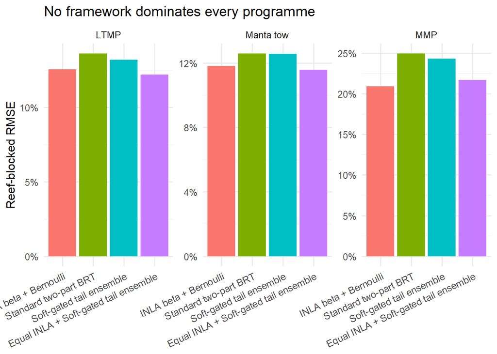

Matched INLA and BRT predictions for 2024

| Programme | Model | RMSE | Predictive R2 | Severe predicted | Severe observed | False extreme |
| --- | --- | --- | --- | --- | --- | --- |
| LTMP | Equal INLA + Soft-gated tail ensemble | 11.4% | 0.467 | 53.9% | 62.0% | 4.4% |
| LTMP | INLA beta + Bernoulli | 11.5% | 0.455 | 54.8% | 62.0% | 2.9% |
| LTMP | Soft-gated tail ensemble | 13.7% | 0.230 | 52.9% | 62.0% | 8.8% |
| LTMP | Standard two-part BRT | 13.6% | 0.239 | 39.8% | 62.0% | 5.9% |
| Manta tow | Equal INLA + Soft-gated tail ensemble | 15.6% | 0.239 | 31.8% | 58.0% | 4.7% |
| Manta tow | INLA beta + Bernoulli | 15.9% | 0.208 | 28.4% | 58.0% | 1.6% |
| Manta tow | Soft-gated tail ensemble | 16.9% | 0.110 | 35.2% | 58.0% | 10.9% |
| Manta tow | Standard two-part BRT | 17.2% | 0.071 | 31.4% | 58.0% | 4.7% |
| MMP | Equal INLA + Soft-gated tail ensemble | 25.5% | 0.120 | 35.3% | 64.4% | 33.3% |
| MMP | INLA beta + Bernoulli | 24.9% | 0.161 | 35.5% | 64.4% | 16.7% |
| MMP | Soft-gated tail ensemble | 27.8% | -0.042 | 35.0% | 64.4% | 36.1% |
| MMP | Standard two-part BRT | 29.5% | -0.173 | 23.9% | 64.4% | 19.4% |

INLA is especially useful for LTMP 2024: its severe mean is 54.8% versus 62.0% observed. The tail BRT adds more for Manta. For MMP, INLA improves general fit while the tail BRT responds more strongly to severe cases but raises false alarms. A single equal blend should therefore not be forced across programmes.

## Joint compound-risk curves

Unlike the earlier one-at-a-time curves, these profiles move Acropora, thermal novelty, coastal rainfall, coloured-water exposure and cloud together. High risk uses high quantiles of the first four and low cloud. These are conditional predictions rather than causal effects.

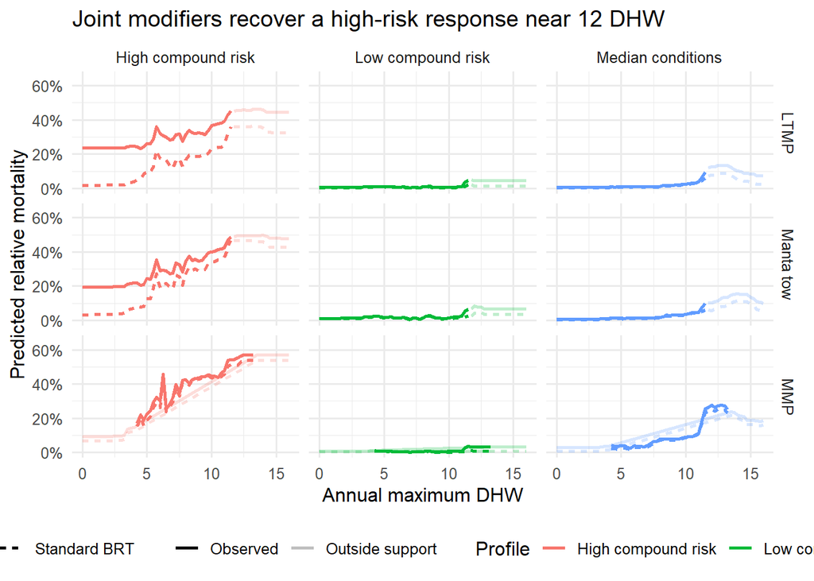

At 11.5 DHW, inside every programme’s observed range, high compound risk predicts 35.9% for LTMP, 46.6% for Manta and 51.2% for MMP with the standard BRT. The conservative tail version predicts 45.4%, 48.9% and 54.1%; low-risk profiles remain below 7%. This is much closer to the ecological expectation that about 12 DHW can produce at least 50% mortality in susceptible communities.

The profiles have small local reversals because interaction features are not globally monotone, and trees plateau outside support. The formal BRMS model should impose a smooth monotone thermal response within modifier profiles.

## Component influence

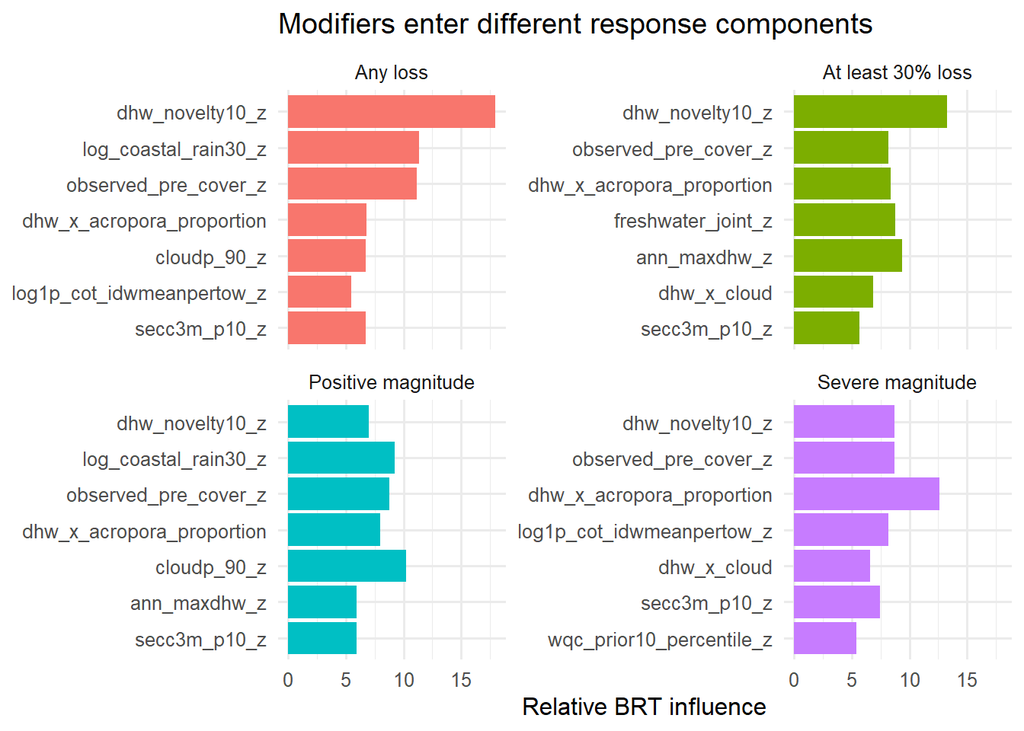

Thermal novelty is the strongest occurrence and tail-gate predictor. Freshwater joint exposure is third in the tail gate, Acropora-by-DHW is important in both magnitude models, and cloud and rainfall are prominent in positive magnitude. These ranks support retention but are not causal effects.

## Reefs helped and harmed

| Set | Programme | Reef | Year | DHW | Observed | Standard | Conservative | Absolute-error improvement |
| --- | --- | --- | --- | --- | --- | --- | --- | --- |
| Largest improvement | LTMP | Lady Musgrave Reef (23-082a) | 2024 | 11.12 | 54.3% | 21.7% | 34.7% | 13.0% |
| Largest improvement | MMP | Fitzroy Island Reef (No 1) (16-054a) | 2024 | 7.82 | 52.4% | 30.7% | 42.1% | 11.4% |
| Largest improvement | MMP | Humpy (Bur-ye-Bur-ye) Reef (23-016) | 2024 | 12.47 | 50.5% | 20.9% | 32.2% | 11.3% |
| Largest improvement | Manta tow | Lady Musgrave Reef (23-082a) | 2024 | 11.12 | 37.8% | 22.1% | 33.1% | 11.0% |
| Largest improvement | MMP | North Keppel (Ko-no-mie) Island Reef (No 2) (23-004b) | 2024 | 12.41 | 65.0% | 17.7% | 27.9% | 10.2% |
| Largest improvement | MMP | Fitzroy Island Reef (No 1) (16-054a) | 2024 | 7.82 | 26.9% | 16.3% | 25.9% | 9.6% |
| Largest improvement | MMP | Humpy (Bur-ye-Bur-ye) Reef (23-016) | 2024 | 12.47 | 53.7% | 28.1% | 37.5% | 9.5% |
| Largest improvement | MMP | North Keppel (Ko-no-mie) Island Reef (No 2) (23-004b) | 2024 | 12.41 | 63.2% | 28.3% | 37.0% | 8.7% |
| Largest deterioration | MMP | Fitzroy Island Reef (No 1) (16-054a) | 2024 | 7.82 | 0.0% | 20.1% | 29.0% | -8.9% |
| Largest deterioration | MMP | Fitzroy Island Reef (No 1) (16-054a) | 2024 | 7.82 | 8.0% | 22.2% | 30.6% | -8.4% |
| Largest deterioration | MMP | Middle (Ba-la-ba) Island Reef (23-010) | 2024 | 12.23 | 28.9% | 34.5% | 41.3% | -6.8% |
| Largest deterioration | Manta tow | Lagoon Reef (12-061) | 2024 | 5.54 | 19.8% | 22.7% | 29.5% | -6.8% |
| Largest deterioration | Manta tow | Feather Reef (17-034) | 2024 | 5.54 | 0.0% | 12.7% | 19.3% | -6.7% |
| Largest deterioration | MMP | Snapper Reef (16-006) | 2017 | 11.65 | 0.0% | 27.7% | 34.3% | -6.7% |

Largest gains include severe 2024 losses at Lady Musgrave, Fitzroy Island, Humpy and North Keppel. The cost is overprediction of some low-loss observations, including repeated MMP observations at Fitzroy. This within-reef disagreement reinforces the need for a shared ecological state with programme-specific observation layers.

## Formal next model

1. Use Acropora proportion, total pre-event cover and their DHW interaction; keep absolute Acropora cover as a sensitivity.
2. Retain Bernoulli occurrence and conditional beta magnitude. Add a continuous tail mixture or robust event-level scale rather than deleting observations.
3. Include DHW interactions for Acropora, novelty, freshwater/coloured water and cloud, partially pooled across programme observation layers.
4. Estimate BRT/BRMS stacking weights inside nested reef-blocked and leave-event-out validation. Keep 2024 in at least one operational candidate while retaining a forward-event stress test.
5. Publish general, conservative and high-risk predictions separately.

Implementation: scripts/fit_joint_extreme_relative_screen.R, scripts/combine_relative_framework_predictions.R, output/joint_extreme_relative/, and this report.